[figure not shown]

# Part-01

The generative models are unsupervised machine learning techniques. The goal of generative models is *"To learn the mapping between input data and output using distribution and patterns from the input."*

> The generative models are capable of the learning representation of high-dimensional data onto lower-dimensional vector space, i.e., the parameters of generative models are less than the amount of training data.

The famous examples of generative models are:

1. Autoencoders
2. GANs
3. Diffusion Models
4. Autoregressive Models

Lets start discussions with "AUTOENCODERS"

## "AUTOENCODERS"

[figure not shown]

Figure 1: Autoencoder Model Architecture[Sourec: https://editor.analyticsvidhya.com/uploads/98612autoencoder.JPG].

"Autoencoders" learns the dense representation of the input and store it in latent representation or coding without any supervision. The dimensions of latent representation are significantly less than the input dimensions. Since autoencoders try to reconstruct the input from stored latent space, hence the term "auto" is used in its name.

Autoencoder is always composed of the following parts:

- **Bottelneck Layer:** The middlemost layer where the inputs are stored as lower dimensional latent space.
- **Encoder or Recognition Network:** That converts input to a latent representation.
- **Decoder or Generative Network:** It reconstructs the input from latent representation.

The bottleneck layer has a lower dimensional representation of input images. The advantages of the bottleneck are, first, that similar images will have similar latent representations, and the second advantage is that by changing the node values of latent space, we can change the output; therefore, it can be used for solving many problems, such as:

- Identifying simmilar images
- Enhancing Images
- Denoising
- Domain Transfer
- Generating New Images

In the subsequent sections, we will explore the implementation of autoencoders and their different types+implementations.

## Section - 1: Implementation of Autoencoder

Step1: Importing relevent packages

**Note:**  
importing  
**1. torch_snipptes:** This package imports all the necessary libraries. (https://pypi.org/project/torch-snippets/)  
**2. torch_summary:** to check the dimensions of pytorch model.

```python
#importing Lib.
from torch_snippets import *

import torch
import torchvision
from torch import nn

from torchvision.datasets import FashionMNIST
from torchvision import transforms
from torchsummary import summary

from tqdm import tqdm

# seting device - cuda if avaialable
device = 'cuda' if torch.cuda.is_available() else 'cpu'

print(f"Torch version : {torch.__version__} & torchvision version: {torchvision.__version__}, Device is set to '{device}'")
```

```
Torch version : 2.0.1 & torchvision version: 0.15.2, Device is set to 'cuda'
```

Step 2 (a): Loading, transforming and preparing data for training autoencoders.

```python
# defining transformatons for images
img_transform = transforms.Compose([transforms.ToTensor(), # convert image to tensor
                                    transforms.Normalize([0.5], [0.5]), # normalizing image with mean 0.5 and std 0.5
                                    transforms.Lambda(lambda x: x.to(device)) # loading data on GPU
                                    ])

# create training and validation dataset (ds) - downloading and saving dataset in "data/content" folder
train_ds = FashionMNIST('data/content', transform = img_transform, train=True, download=True)
val_ds = FashionMNIST('data/content', transform = img_transform, train=False, download=True)

# defining dataloaders:
BATCH_SIZE = 128
train_dl = DataLoader(train_ds, batch_size=BATCH_SIZE, shuffle=True)
val_dl = DataLoader(val_ds, batch_size=BATCH_SIZE, shuffle=False)
```

Step 2 (b): Visualizing the train and val. data.

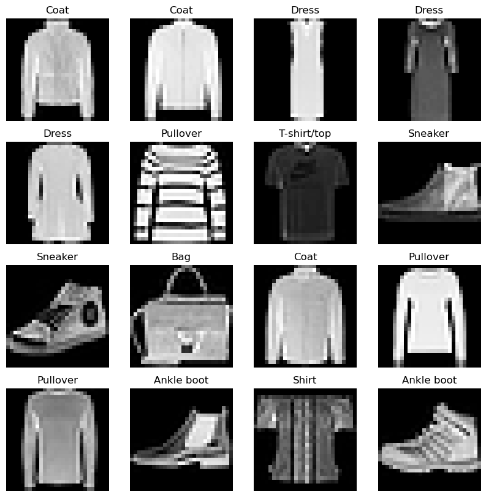

```python
fig = plt.figure(figsize=(10,10))
rows, cols = (4,4)
for i in range(1, rows*cols +1):
    random_idx = torch.randint(0, len(train_ds), size=[1]).item()
    img, label = train_ds[random_idx]
    fig.add_subplot(rows, cols, i)
    plt.imshow(img.cpu().squeeze(), cmap="gray")
    plt.title(train_ds.classes[label])
    plt.axis(False)
```

Step 3 : Creating Autoencoder Model.

```python
class Autoencoder(nn.Module):
    """
    Vanila Autoencoder Model - for 28*28 - gray images
    Inputs- latent_dim:int
    """
    def __init__(self, latent_dim:int):
        super().__init__()
        self.latent_dim = latent_dim

        # defining encoder
        self.encoder = nn.Sequential(nn.Linear(28*28,128),
                                     nn.ReLU(True),
                                     nn.Linear(128,64),
                                     nn.ReLU(True),
                                     nn.Linear(64, self.latent_dim))

        self.decoder = nn.Sequential(nn.Linear(self.latent_dim,64),
                                     nn.ReLU(True),
                                     nn.Linear(64,128),
                                     nn.ReLU(True),
                                     nn.Linear(128, 28*28),
                                     nn.Tanh())

    # defining forward pass
    def forward(self, x:torch.Tensor):
        x = x.view(len(x),-1)
        x = self.encoder(x)
        x = self.decoder(x)
        x = x.view(len(x), 1, 28, 28)
        return x

# checking Autoecoder Model Architecture
model = Autoencoder(2).to(device)
print(summary(model, torch.zeros(2,1,28,28)))
```

```
==========================================================================================
Layer (type:depth-idx)                   Output Shape              Param #
==========================================================================================
├─Sequential: 1-1                        [-1, 2]                   --
|    └─Linear: 2-1                       [-1, 128]                 100,480
|    └─ReLU: 2-2                         [-1, 128]                 --
|    └─Linear: 2-3                       [-1, 64]                  8,256
|    └─ReLU: 2-4                         [-1, 64]                  --
|    └─Linear: 2-5                       [-1, 2]                   130
├─Sequential: 1-2                        [-1, 784]                 --
|    └─Linear: 2-6                       [-1, 64]                  192
|    └─ReLU: 2-7                         [-1, 64]                  --
|    └─Linear: 2-8                       [-1, 128]                 8,320
|    └─ReLU: 2-9                         [-1, 128]                 --
|    └─Linear: 2-10                      [-1, 784]                 101,136
|    └─Tanh: 2-11                        [-1, 784]                 --
==========================================================================================
Total params: 218,514
Trainable params: 218,514
Non-trainable params: 0
Total mult-adds (M): 0.43
==========================================================================================
Input size (MB): 0.01
Forward/backward pass size (MB): 0.01
Params size (MB): 0.83
Estimated Total Size (MB): 0.85
==========================================================================================
```

[output not shown]

Step 4 : Defining Training Loop.

```
EPOCH: 1.000  val_loss: 0.104  train_loss: 0.141  (27.25s - 245.22s remaining)
EPOCH: 2.000  val_loss: 0.098  train_loss: 0.100  (58.31s - 233.22s remaining)
EPOCH: 3.000  val_loss: 0.095  train_loss: 0.096  (90.67s - 211.55s remaining)
EPOCH: 4.000  val_loss: 0.093  train_loss: 0.093  (123.67s - 185.51s remaining)
EPOCH: 5.000  val_loss: 0.091  train_loss: 0.091  (157.01s - 157.01s remaining)
EPOCH: 6.000  val_loss: 0.090  train_loss: 0.090  (188.78s - 125.85s remaining)
EPOCH: 7.000  val_loss: 0.089  train_loss: 0.088  (219.21s - 93.95s remaining)
EPOCH: 8.000  val_loss: 0.088  train_loss: 0.087  (250.12s - 62.53s remaining)
EPOCH: 9.000  val_loss: 0.088  train_loss: 0.087  (281.20s - 31.24s remaining)
EPOCH: 10.000  val_loss: 0.088  train_loss: 0.086  (314.44s - 0.00s remaining)
```

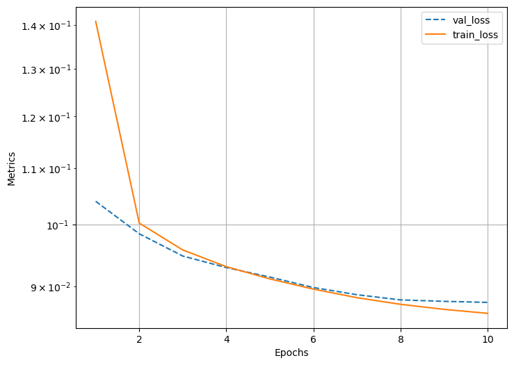

```python
# defining the function  for training loop
def train_batch (inp:torch.Tensor, model: torch.nn.Module,
                criterion: torch.nn.Module,
                optimizer: torch.optim.Optimizer,):
    """
    Training Loop
    """
    model.train()
    optimizer.zero_grad()
    output = model(inp)
    loss = criterion(output, inp)
    loss.backward()
    optimizer.step()
    return loss

# defining the validation step
@torch.no_grad()
def val_batch(inp:torch.Tensor, model: torch.nn.Module,
                criterion: torch.nn.Module):
    """
    Validation Loop
    """
    model.eval()
    output = model(inp)
    loss = criterion(output, inp)
    return loss

# defining Criterion(Loss_functions) and optimizer

model = Autoencoder(3).to(device)

criterion = nn.MSELoss()

optimizer = torch.optim.AdamW(model.parameters(), lr = 0.001, weight_decay=1e-5)

# define num_epochs

num_epochs = 10
log = Report(num_epochs)



for epoch in range(num_epochs):
    N = len(train_dl)
    for ix, (data, _) in enumerate(train_dl):
        tr_loss = train_batch(data,model,criterion,optimizer)
        log.record(pos =(epoch+(ix+1) /N), train_loss = tr_loss, end='\r')

    N = len(val_dl)
    for ix, (data, _) in enumerate(val_dl):
        loss = val_batch(data,model,criterion)
        log.record(pos =(epoch+(ix+1) /N), val_loss = loss, end='\r')
    log.report_avgs(epoch+1)


log.plot_epochs(log=True)
```

Step 5 : Validating Results using validation dataset.

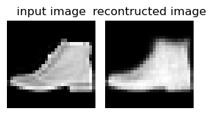

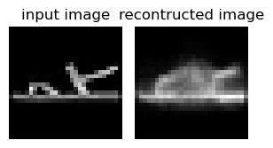

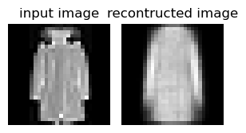

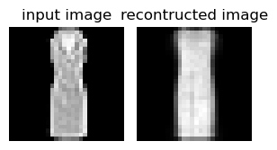

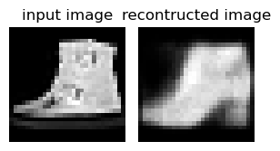

```python
for _ in range(5):
    random_idx = torch.randint(0, len(val_ds), size=[1]).item()
    im , _ = val_ds[random_idx]
    pred_im = model(im[None]).cpu()[0]
    fig,ax = plt.subplots(1,2,figsize=(3,3))
    show(im[0],ax=ax[0],title='input image')
    show(pred_im[0],ax=ax[1],title='recontructed image')
    plt.tight_layout()
    plt.show()
```